# 04 KSM campaign model

# Goal

Supplement the previous models with Kellogg-specific datapoints previously used for the [AF $10K model](https://github.com/phively/ksm-models/tree/master/af-10k-fy17), assess how well the PG checklist applies to Kellogg donors, and build a basic campaign prioritization model using all variables.

# Setup

```r
library(tidyverse)
library(gridExtra)
library(splines)
library(foreach)
library(lubridate)
library(wranglR)
# Functions adapted from previous analysis steps
source('code/functions.R')
# Visualization functions adapted fron previous analysis steps
source('code/functions_viz.R')
```

## Import data

The PG checklist data file is generated with [this code](https://github.com/phively/ksm-models/blob/master/pg-cultivation-score-fy18/code/generate-data.R), while the KSM data is derived from the 1/9/2018 version of [this view](https://github.com/phively/ksm-models/blob/master/af-10k-fy17/data/ksm-af-10k-data.sql), transformed by [a script](https://github.com/phively/ksm-models/blob/master/pg-cultivation-score-fy18/code/generate-af10k-data.R).

```r
date <- '2018-09-07'
# Load PG data
filepath <- paste0('data/', date, ' PG scores for all active prospects.xlsx')
source('code/generate-data.R')
source('code/generate-modeling-data.R')
# Preserve ID numbers
mdat <- pool %>% select(ID_NUMBER) %>% cbind(mdat)
# Load AF 10K data
filepath <- paste0('data/', date, ' AF 10K model data.csv')
source('code/generate-af10k-data.R')
dat10k <- parse_af_data(filepath)
```

# KSM and NU model comparison

## Campaign vs. PG checklist

Does fitting the PG checklist on all prospects, versus Kellogg prospects only, show some difference? How does the model change when fitting just KSM prospects, as opposed to the entire prospect pool?

```r
# Full dataset
chklm_full <- lm(
  log10plus1(CAMPAIGN_NEWGIFT_CMIT_CREDIT) ~
    ACTIVE_PROPOSALS +
    AGE +
    PM_VISIT_LAST_2_YRS +
    VISITS_5PLUS +
    AF_25K_GIFT +
    GAVE_IN_LAST_3_YRS +
    MG_250K_PLUS +
    PRESIDENT_VISIT +
    TRUSTEE_OR_ADVISORY_BOARD +
    Alumnus +
    DEEP_ENGAGEMENT +
    CHICAGO_HOME
  , data = mdat
)
# KSM prospects only
chklm_ksm <- lm(
  log10plus1(CAMPAIGN_NEWGIFT_CMIT_CREDIT) ~
    ACTIVE_PROPOSALS +
    AGE +
    PM_VISIT_LAST_2_YRS +
    VISITS_5PLUS +
    AF_25K_GIFT +
    GAVE_IN_LAST_3_YRS +
    MG_250K_PLUS +
    PRESIDENT_VISIT +
    TRUSTEE_OR_ADVISORY_BOARD +
    Alumnus +
    DEEP_ENGAGEMENT +
    CHICAGO_HOME
  , data = mdat %>% inner_join(dat10k %>% select(ID_NUMBER), by = c('ID_NUMBER', 'ID_NUMBER'))
)
```

The full model is fit on all 26261 observations, while the KSM model uses only 8024 of them.

```r
model_comparison <- full_join(
  data.frame(
    var = coef(chklm_full) %>% names
    , full.model = coef(chklm_full)
    , se.full = summary(chklm_full)$coefficients[, 2]
  )
  , data.frame(
    var = coef(chklm_ksm) %>% names
    , ksm.model = coef(chklm_ksm)
    , se.ksm = summary(chklm_ksm)$coefficients[, 2]
  )
  , by = c('var', 'var')
)
```

```r
model_comparison %>%
  mutate_if(is.numeric, function(x) round(x, 3))
```

| var | full.model | se.full | ksm.model | se.ksm |
| --- | --- | --- | --- | --- |
| (Intercept) | 1.377 | 0.024 | 1.713 | 0.088 |
| ACTIVE_PROPOSALS | 0.279 | 0.040 | 0.441 | 0.073 |
| AGE | -0.187 | 0.018 | -0.215 | 0.034 |
| PM_VISIT_LAST_2_YRS | 0.586 | 0.042 | 0.361 | 0.080 |
| VISITS_5PLUS | 0.751 | 0.030 | 0.794 | 0.053 |
| AF_25K_GIFT | 0.906 | 0.050 | 0.906 | 0.081 |
| GAVE_IN_LAST_3_YRS | 1.990 | 0.020 | 2.005 | 0.037 |
| MG_250K_PLUS | 1.048 | 0.087 | 0.932 | 0.144 |
| PRESIDENT_VISIT | 0.415 | 0.074 | 0.395 | 0.122 |
| TRUSTEE_OR_ADVISORY_BOARD | 0.290 | 0.039 | 0.238 | 0.075 |

[output cut: 3 more lines]

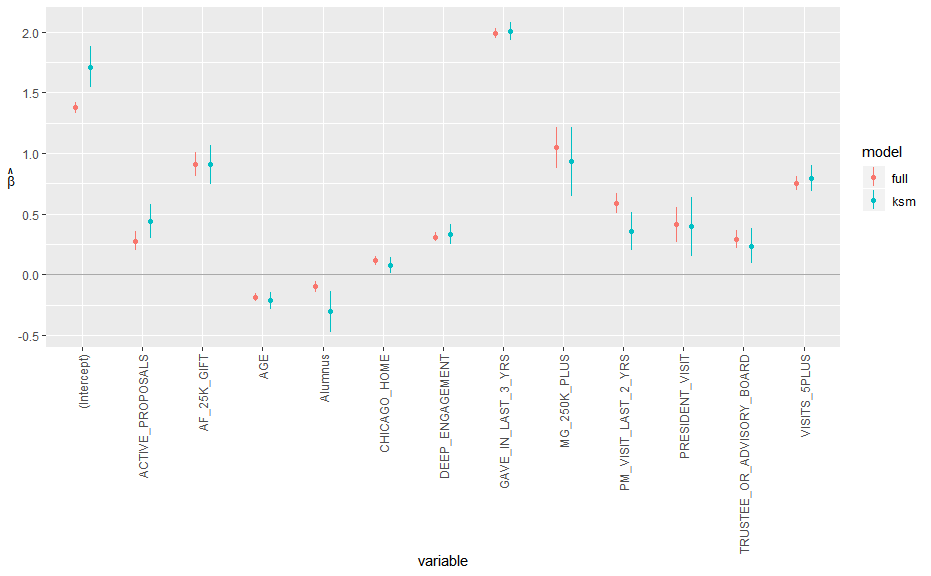

```r
pcrit <- .05
critq <- qnorm(p = pcrit/2, lower.tail = FALSE)
model_comparison %>%
  gather('which', 'x', -(var)) %>%
  mutate(
    model = case_when(
      str_detect(which, '.*full.*') ~ 'full'
      , str_detect(which, '.*ksm.*') ~ 'ksm'
    ) %>% factor()
    , which = case_when(
      str_detect(which, '.*model.*') ~ 'beta'
      , TRUE ~ 'se'
    )
  ) %>%
  spread(which, x) %>%
  mutate(
    se.high = beta + se * critq
    , se.low = beta - se * critq
  ) %>%
  ggplot(aes(x = var, y = beta, color = model, group = model)) +
  geom_hline(yintercept = 0, color = 'darkgray') +
  geom_point(position = position_dodge(.5)) +
  geom_linerange(aes(ymin = se.low, ymax = se.high), position = position_dodge(.5)) +
  theme(axis.text.x = element_text(angle = 90, hjust = 1, vjust = .5), axis.title.y = element_text(angle = 0, vjust = .5)) +
  labs(x = 'variable', y = bquote(hat(beta)))
```

The bars provide 95% CIs for each coefficient based on the standard error. Not much here; there isn’t an apparent difference for the variables of interest. How about the final campaign model?

## Interaction model

To be more rigorous, consider a “KSM prospect” indicator, with interaction effects on each of the explanatory variables.

```r
clm_ksm_interact <- lm(
  log10plus1(CAMPAIGN_NEWGIFT_CMIT_CREDIT) ~
    # KSM interaction
    KSM *
    (
    ns(NUMERIC_AGE, df = 5) + # Underlying variable to AGE indicator
    PM_VISIT_LAST_2_YRS +
    log10plus1(VISIT_COUNT) + # Underlying VISITS_5PLUS indicator
    AF_25K_GIFT +
    sqrt(YEARS_OF_GIVING) + # Underlying GAVE_IN_LAST_3_YRS
    ns(YEARS_OF_GIVING_LAST_3, df = 2) + # Underlying GAVE_IN_LAST_3_YRS
    MG_250K_PLUS + # Decided to leave as factor
    Alumnus +
    SEASON_TICKET_YEARS + # Deep Engagement component
    AFFINITY_SCORE +
    MG_PR_MODEL_DESC +
    1
    )
  , data = mdat %>%
      # People on the 10K list count as KSM prospects
      left_join(dat10k %>% select(ID_NUMBER) %>% mutate(KSM = 'Y')
                , by = c('ID_NUMBER', 'ID_NUMBER')) %>%
      # Replace NAs from the left join with N indicator
      replace_na(replace = list(KSM = 'N'))
)
```

```r
summary(clm_ksm_interact)
```

```
Call:
lm(formula = log10plus1(CAMPAIGN_NEWGIFT_CMIT_CREDIT) ~ KSM *
    (ns(NUMERIC_AGE, df = 5) + PM_VISIT_LAST_2_YRS + log10plus1(VISIT_COUNT) +
        AF_25K_GIFT + sqrt(YEARS_OF_GIVING) + ns(YEARS_OF_GIVING_LAST_3,
        df = 2) + MG_250K_PLUS + Alumnus + SEASON_TICKET_YEARS +
        AFFINITY_SCORE + MG_PR_MODEL_DESC + 1), data = mdat %>%
    left_join(dat10k %>% select(ID_NUMBER) %>% mutate(KSM = "Y"),
        by = c("ID_NUMBER", "ID_NUMBER")) %>% replace_na(replace = list(KSM = "N")))

Residuals:
    Min      1Q  Median      3Q     Max
-4.5561 -0.7164 -0.1432  0.6508  6.0867

Coefficients: (2 not defined because of singularities)
                                           Estimate Std. Error t value Pr(>|t|)
(Intercept)                               10.183118   0.230481  44.182  < 2e-16 ***
KSMY                                      -0.421533   0.450147  -0.936 0.349058
ns(NUMERIC_AGE, df = 5)1                   0.346903   0.095193   3.644 0.000269 ***
ns(NUMERIC_AGE, df = 5)2                   0.183271   0.111204   1.648 0.099352 .
ns(NUMERIC_AGE, df = 5)3                  -0.443439   0.080768  -5.490 4.05e-08 ***
ns(NUMERIC_AGE, df = 5)4                   0.368468   0.244266   1.508 0.131447
ns(NUMERIC_AGE, df = 5)5                  -0.243512   0.171839  -1.417 0.156467
PM_VISIT_LAST_2_YRS                        0.356464   0.030520  11.680  < 2e-16 ***
log10plus1(VISIT_COUNT)                    0.188413   0.031654   5.952 2.68e-09 ***
AF_25K_GIFT                                0.514055   0.048835  10.526  < 2e-16 ***
sqrt(YEARS_OF_GIVING)                      0.263469   0.007246  36.363  < 2e-16 ***
ns(YEARS_OF_GIVING_LAST_3, df = 2)1      -17.538996   0.374487 -46.835  < 2e-16 ***
ns(YEARS_OF_GIVING_LAST_3, df = 2)2              NA         NA      NA       NA
MG_250K_PLUS                               0.910132   0.081097  11.223  < 2e-16 ***
Alumnus                                   -0.733612   0.021768 -33.701  < 2e-16 ***
SEASON_TICKET_YEARS                       -0.026651   0.004370  -6.098 1.09e-09 ***
AFFINITY_SCORE                             0.208596   0.007613  27.402  < 2e-16 ***
MG_PR_MODEL_DESCBottom Tier               -0.157036   0.023298  -6.740 1.61e-11 ***
MG_PR_MODEL_DESCMiddle Tier                0.202653   0.029935   6.770 1.32e-11 ***
MG_PR_MODEL_DESCTop Tier                   0.626873   0.029945  20.934  < 2e-16 ***
KSMY:ns(NUMERIC_AGE, df = 5)1             -0.554229   0.206857  -2.679 0.007382 **
KSMY:ns(NUMERIC_AGE, df = 5)2             -0.534767   0.237156  -2.255 0.024147 *
KSMY:ns(NUMERIC_AGE, df = 5)3             -0.776567   0.162550  -4.777 1.79e-06 ***
KSMY:ns(NUMERIC_AGE, df = 5)4             -1.184431   0.516106  -2.295 0.021745 *
KSMY:ns(NUMERIC_AGE, df = 5)5             -0.807527   0.351630  -2.297 0.021654 *
KSMY:PM_VISIT_LAST_2_YRS                  -0.108286   0.057493  -1.883 0.059648 .
KSMY:log10plus1(VISIT_COUNT)               0.273587   0.055291   4.948 7.54e-07 ***
KSMY:AF_25K_GIFT                           0.133567   0.077001   1.735 0.082821 .
KSMY:sqrt(YEARS_OF_GIVING)                 0.142176   0.012810  11.099  < 2e-16 ***
KSMY:ns(YEARS_OF_GIVING_LAST_3, df = 2)1   1.947077   0.691022   2.818 0.004841 **
KSMY:ns(YEARS_OF_GIVING_LAST_3, df = 2)2         NA         NA      NA       NA
KSMY:MG_250K_PLUS                          0.106008   0.131643   0.805 0.420670
KSMY:Alumnus                               0.040761   0.067507   0.604 0.545977
KSMY:SEASON_TICKET_YEARS                  -0.013608   0.008073  -1.686 0.091865 .
KSMY:AFFINITY_SCORE                       -0.069851   0.013357  -5.229 1.71e-07 ***
KSMY:MG_PR_MODEL_DESCBottom Tier          -0.062164   0.043760  -1.421 0.155453
KSMY:MG_PR_MODEL_DESCMiddle Tier          -0.117576   0.056300  -2.088 0.036772 *
KSMY:MG_PR_MODEL_DESCTop Tier             -0.281960   0.055685  -5.063 4.15e-07 ***
---
Signif. codes:  0 ‘***’ 0.001 ‘**’ 0.01 ‘*’ 0.05 ‘.’ 0.1 ‘ ’ 1

Residual standard error: 1.024 on 26225 degrees of freedom
Multiple R-squared:  0.6893,    Adjusted R-squared:  0.6889
F-statistic:  1662 on 35 and 26225 DF,  p-value: < 2.2e-16
```

Note the NAs due to collinearity; this should be fixed.

```r
clm_ksm_interact <- update(
  clm_ksm_interact
  , formula = . ~ .
      - (ns(YEARS_OF_GIVING_LAST_3, df = 2) * KSM)
      + (YEARS_OF_GIVING_LAST_3 * KSM)
)
```

```r
summary(clm_ksm_interact)
```

```
Call:
lm(formula = log10plus1(CAMPAIGN_NEWGIFT_CMIT_CREDIT) ~ ns(NUMERIC_AGE,
    df = 5) + PM_VISIT_LAST_2_YRS + log10plus1(VISIT_COUNT) +
    AF_25K_GIFT + sqrt(YEARS_OF_GIVING) + MG_250K_PLUS + Alumnus +
    SEASON_TICKET_YEARS + AFFINITY_SCORE + MG_PR_MODEL_DESC +
    YEARS_OF_GIVING_LAST_3 + KSM + KSM:ns(NUMERIC_AGE, df = 5) +
    KSM:PM_VISIT_LAST_2_YRS + KSM:log10plus1(VISIT_COUNT) + KSM:AF_25K_GIFT +
    KSM:sqrt(YEARS_OF_GIVING) + KSM:MG_250K_PLUS + KSM:Alumnus +
    KSM:SEASON_TICKET_YEARS + KSM:AFFINITY_SCORE + KSM:MG_PR_MODEL_DESC +
    KSM:YEARS_OF_GIVING_LAST_3, data = mdat %>% left_join(dat10k %>%
    select(ID_NUMBER) %>% mutate(KSM = "Y"), by = c("ID_NUMBER",
    "ID_NUMBER")) %>% replace_na(replace = list(KSM = "N")))

Residuals:
    Min      1Q  Median      3Q     Max
-4.5561 -0.7164 -0.1432  0.6508  6.0867

Coefficients:
                                  Estimate Std. Error t value Pr(>|t|)
(Intercept)                       0.504864   0.103428   4.881 1.06e-06 ***
ns(NUMERIC_AGE, df = 5)1          0.346903   0.095193   3.644 0.000269 ***
ns(NUMERIC_AGE, df = 5)2          0.183271   0.111204   1.648 0.099352 .
ns(NUMERIC_AGE, df = 5)3         -0.443439   0.080768  -5.490 4.05e-08 ***
ns(NUMERIC_AGE, df = 5)4          0.368468   0.244266   1.508 0.131447
ns(NUMERIC_AGE, df = 5)5         -0.243512   0.171839  -1.417 0.156467
PM_VISIT_LAST_2_YRS               0.356464   0.030520  11.680  < 2e-16 ***
log10plus1(VISIT_COUNT)           0.188413   0.031654   5.952 2.68e-09 ***
AF_25K_GIFT                       0.514055   0.048835  10.526  < 2e-16 ***
sqrt(YEARS_OF_GIVING)             0.263469   0.007246  36.363  < 2e-16 ***
MG_250K_PLUS                      0.910132   0.081097  11.223  < 2e-16 ***
Alumnus                          -0.733612   0.021768 -33.701  < 2e-16 ***
SEASON_TICKET_YEARS              -0.026651   0.004370  -6.098 1.09e-09 ***
AFFINITY_SCORE                    0.208596   0.007613  27.402  < 2e-16 ***
MG_PR_MODEL_DESCBottom Tier      -0.157036   0.023298  -6.740 1.61e-11 ***
MG_PR_MODEL_DESCMiddle Tier       0.202653   0.029935   6.770 1.32e-11 ***
MG_PR_MODEL_DESCTop Tier          0.626873   0.029945  20.934  < 2e-16 ***
YEARS_OF_GIVING_LAST_3            0.624390   0.013332  46.835  < 2e-16 ***
KSMY                              0.652890   0.230228   2.836 0.004574 **
ns(NUMERIC_AGE, df = 5)1:KSMY    -0.554229   0.206857  -2.679 0.007382 **
ns(NUMERIC_AGE, df = 5)2:KSMY    -0.534767   0.237156  -2.255 0.024147 *
ns(NUMERIC_AGE, df = 5)3:KSMY    -0.776567   0.162550  -4.777 1.79e-06 ***
ns(NUMERIC_AGE, df = 5)4:KSMY    -1.184431   0.516106  -2.295 0.021745 *
ns(NUMERIC_AGE, df = 5)5:KSMY    -0.807527   0.351630  -2.297 0.021654 *
PM_VISIT_LAST_2_YRS:KSMY         -0.108286   0.057493  -1.883 0.059648 .
log10plus1(VISIT_COUNT):KSMY      0.273587   0.055291   4.948 7.54e-07 ***
AF_25K_GIFT:KSMY                  0.133567   0.077001   1.735 0.082821 .
sqrt(YEARS_OF_GIVING):KSMY        0.142176   0.012810  11.099  < 2e-16 ***
MG_250K_PLUS:KSMY                 0.106008   0.131643   0.805 0.420670
Alumnus:KSMY                      0.040761   0.067507   0.604 0.545977
SEASON_TICKET_YEARS:KSMY         -0.013608   0.008073  -1.686 0.091865 .
AFFINITY_SCORE:KSMY              -0.069851   0.013357  -5.229 1.71e-07 ***
MG_PR_MODEL_DESCBottom Tier:KSMY -0.062164   0.043760  -1.421 0.155453
MG_PR_MODEL_DESCMiddle Tier:KSMY -0.117576   0.056300  -2.088 0.036772 *
MG_PR_MODEL_DESCTop Tier:KSMY    -0.281960   0.055685  -5.063 4.15e-07 ***
YEARS_OF_GIVING_LAST_3:KSMY      -0.069316   0.024600  -2.818 0.004841 **
---
Signif. codes:  0 ‘***’ 0.001 ‘**’ 0.01 ‘*’ 0.05 ‘.’ 0.1 ‘ ’ 1

Residual standard error: 1.024 on 26225 degrees of freedom
Multiple R-squared:  0.6893,    Adjusted R-squared:  0.6889
F-statistic:  1662 on 35 and 26225 DF,  p-value: < 2.2e-16
```

```r
interact_model <- cbind(
  data.frame(var = summary(clm_ksm_interact)$coefficients %>% rownames())
  , beta = summary(clm_ksm_interact)$coefficients[, 1]
  , se = summary(clm_ksm_interact)$coefficients[, 2]
)
row.names(interact_model) <- NULL
```

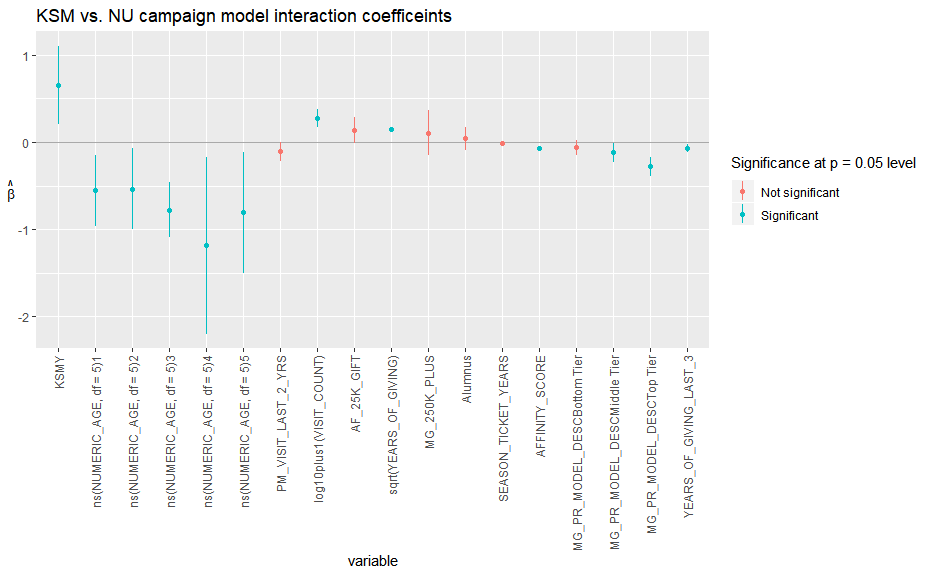

```r
interact_model %>%
  filter(str_detect(var, 'KSMY')) %>%
  mutate(
    var = str_remove(var, ':KSMY') %>% as_factor()
    , se.high = beta + se * critq
    , se.low = beta - se * critq
    # SE bars cross 0 iff not significant at pcrit
    , sig = ifelse(se.high > 0 & se.low < 0, 'Not significant', 'Significant')
  ) %>%
  ggplot(aes(x = var, y = beta, color = sig)) +
  geom_hline(yintercept = 0, color = 'darkgray') +
  geom_point() +
  geom_linerange(aes(ymin = se.low, ymax = se.high)) +
  theme(axis.text.x = element_text(angle = 90, hjust = 1, vjust = .5), axis.title.y = element_text(angle = 0, vjust = .5)) +
  labs(
    title = 'KSM vs. NU campaign model interaction coefficeints'
    , x = 'variable'
    , y = bquote(hat(beta))
    , color = bquote('Significance at p =' ~ .(pcrit) ~ 'level')
  )
```

Looks like there *is* a KSM main effect (KSMY is the KSM effect), plus there are differences in the age (less impact), total visit count (more impact), years of giving (including last 3, at the end), affinity score (slightly less impact), and PG prioritization model factors (less impact).

```r
interact_compare <- interact_model %>%
  filter(str_detect(var, 'NUMERIC_AGE|VISIT_COUNT|YEARS_OF_GIVING|AFFINITY|MG_PR')) %>%
  mutate(
    model = ifelse(str_detect(var, 'KSMY'), 'KSM', 'NU')
    , var = str_remove(var, ':KSMY')
  )
interact_compare <- cbind(
  interact_compare %>% filter(model == 'NU')
  , interact_compare %>% filter(model == 'KSM') %>% select(ksm.effect = beta, ksm.se = se)
) %>% mutate(
  ksm.effect = beta + ksm.effect
) %>% select(-model)
```

```r
interact_compare %>%
  mutate_if(is.numeric, function(x) round(x, 3))
```

| var | beta | se | ksm.effect | ksm.se |
| --- | --- | --- | --- | --- |
| ns(NUMERIC_AGE, df = 5)1 | 0.347 | 0.095 | -0.207 | 0.207 |
| ns(NUMERIC_AGE, df = 5)2 | 0.183 | 0.111 | -0.351 | 0.237 |
| ns(NUMERIC_AGE, df = 5)3 | -0.443 | 0.081 | -1.220 | 0.163 |
| ns(NUMERIC_AGE, df = 5)4 | 0.368 | 0.244 | -0.816 | 0.516 |
| ns(NUMERIC_AGE, df = 5)5 | -0.244 | 0.172 | -1.051 | 0.352 |
| log10plus1(VISIT_COUNT) | 0.188 | 0.032 | 0.462 | 0.055 |
| sqrt(YEARS_OF_GIVING) | 0.263 | 0.007 | 0.406 | 0.013 |
| AFFINITY_SCORE | 0.209 | 0.008 | 0.139 | 0.013 |
| MG_PR_MODEL_DESCBottom Tier | -0.157 | 0.023 | -0.219 | 0.044 |
| MG_PR_MODEL_DESCMiddle Tier | 0.203 | 0.030 | 0.085 | 0.056 |

[output cut: 2 more lines]

I’ve defined “KSM effect” as the sum of the coefficient and interaction effect estimate, i.e.

$$K_i = \hat{\beta_i} + \hat{\beta}_{i ~ \times KSM}$$

Plotting these variables:

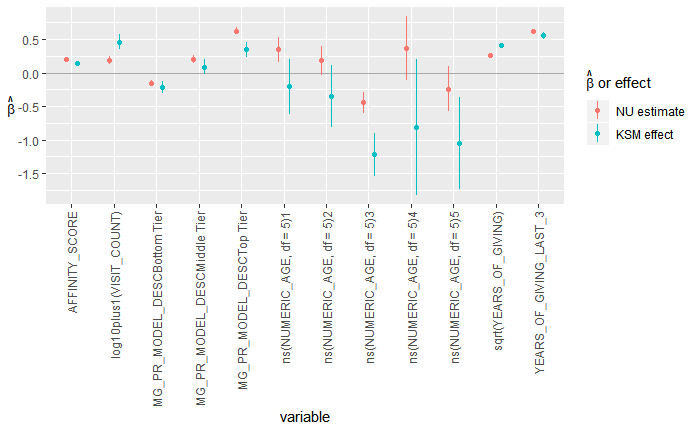

```r
interact_compare %>%
  gather('which', 'x', -(var)) %>%
  mutate(
    model = case_when(
      !str_detect(which, 'ksm.*') ~ 'NU estimate'
      , TRUE ~ 'KSM effect'
    ) %>% as_factor()
    , which = case_when(
      str_detect(which, 'se') ~ 'se'
      , TRUE ~ 'beta'
    )
  ) %>%
  spread(which, x) %>%
  mutate(
    se.high = beta + se * critq
    , se.low = beta - se * critq
  ) %>%
  ggplot(aes(x = var, y = beta, color = model, group = model)) +
  geom_hline(yintercept = 0, color = 'darkgray') +
  geom_point(position = position_dodge(.5)) +
  geom_linerange(aes(ymin = se.low, ymax = se.high), position = position_dodge(.5)) +
  theme(axis.text.x = element_text(angle = 90, hjust = 1, vjust = .5), axis.title.y = element_text(angle = 0, vjust = .5)) +
  labs(x = 'variable', y = bquote(hat(beta)), color = bquote(hat(beta) ~ 'or effect')) +
  scale_y_continuous(breaks = seq(-5, 5, by = .5))
```

This is interesting – there does appear to be evidence that middle tier and top tier aren’t as robust for KSM (coefficients closer to 0), but affinity score still looks pretty good. The practical effect of age coefficient differences for KSM/NU is relatively large, even changing signs for most of the splines. Total visit count and total years of giving is also more impactful for KSM than NU prospects.

## Summary of findings

- KSM and NU constituents behave similarly when looking only at the PG checklist items.
- Given the interaction model results, it probably makes sense to estimate age effects separately for the different units/programs.
- There really are differences between KSM and NU campaign giving not already accounted for in the MG prioritization score. Note that this is **not** the same as saying that expected *future giving* (i.e. the purpose of the model) is different between the populations in some way not accounted for by the MG prioritzation score.
- Affinity score is a marginally less important predictor for KSM than NU prospects. On the other hand, total visit count and total years of giving outperform for KSM compared to NU.
- The previous point may suggest that giving engagement is *more* important for KSM prospects (and potentially even other graduate program prospects) than other NU prospects.

# KSM model goals

The overarching goal is to predict giving over the final two years of the campaign. Ideally, I’d want to find expected future value, not just difference from expected value today. Consider the following:

$$E \left( \text{giving, donor | covariates} \right) = E \left(\text{giving | donor, covariates} \right) P \left(\text{donor | covariates} \right)$$

Estimate the expected future value as the product of an expected value and a probability. This can also be thought of as separate capacity and affinity models, and should give more useful estimates than $E\left( \text{giving | covariates} \right)$, which is left-censored by $0.

It’ll be informative seeing what features are more or less important at each stage of the two-step procedure, though I expect overall accuracy to suffer somewhat. Down the road it would be interesting to compare this to other methods, like trees and boosting.

# KSM model variables

The target variable is the sum of new gifts and commitments from 9/1/16 to 8/31/18 (FY17-18), given the state of the database on 8/31/16 (FY16).

As a general principle, point-in-time data is derived from entered date ranges where possible. Where dates are missing, it will be based upon the date added or date modified audit trail for each field, as suitable. The following data types received this treatment:

- All dollar amounts
- All giving behavior counts and years
- Student/alumni status
- All prospect assignments and ratings
- All contact information and indicators
- Employment
- Visits and outreach
- Engagement counts

This is implemented by [this SQL code](https://github.com/phively/ksm-models/blob/master/pg-cultivation-score-fy18/code/ksm-point-in-time-data-pull.sql).

```r
# Import data
```

# Probability model

Logistic regression has been the workhorse of fundraising models for years. Some special considerations for this application:

- Minimizing predictive error, e.g. finding the model $\text{argmin}_m \sum_i \left[ y_i - \widehat{m}_x(x_i) \right]^2$, on in-sample data is the *wrong* metric!
- Focus on identifying as many current prospects as possible (minimizing type II error); type I is acceptable as these become new prospects.
- Avoid overfitting the training data. Techniques like cross-validation are highly recommended.
- Avoid endogenous variables; in this context, that means those that are causally associated with the outcome being measured, e.g. don’t use `Lifetime.Giving` as a predictor if the response variable is `Largest.Gift`.

I have [previously found](https://github.com/phively/ksm-models/tree/master/af-10k-fy17) that penalized logistic regression, such as implemented in R by the glmnet package, works better than standard logistic regression, so that’s the technique that I’ll use here.